# ANOVA

Morozov Andrii

6 11 2020

##**NIEZBEDNE PAKIETY oraz FUNKCJE**

```r
library(car)
library(ggpubr)
library(onewaytests)
library(psych)
library(nortest)
library(readxl)
library(lsr)
library(sjstats)
CV <- function(.df){
  w <- c(1:ncol(.df))
  for (i in 1:ncol(.df)) {
    w[i] <- sd(.df[[i]], na.rm=TRUE)/mean(.df[[i]], na.rm=TRUE)*100
  }
  return(w)
} # wsp. zmiennosci

setwd("C:/Users/An/Desktop/SAD")

df <- read_xls("mieszkania.xls")
df$dzielnica <- as.factor(df$dzielnica)
df$typ_budynku <- as.factor(df$typ_budynku)
df$pokoi <- as.factor(df$pokoi)

df23 <- read_xls("mieszkaniaC.xls")
df23$dzielnica <- as.factor(df23$dzielnica)
df23$typ_budynku <- as.factor(df23$typ_budynku)
df23$pokoi <- as.factor(df23$pokoi)
```

##**WSTEP**

**Celem projektu** jest przeprowadzenie ANOVA 2-czynnikowej na danych otrzymanych w trakcie zajec projektowych.  
Bedzie podjeta proba ustalenia najlepszej kombinacji czynnikow wplywajacych na zmienna zalezna oraz pomiar efektow koncowych uzyskanych w trakcie projektu.

**Hipoteza badawcza** wyniki dla roznych kombinacji czynnikow **NIE** roznia sie istotnie.

**Opis danych**

```
## tibble [200 x 6] (S3: tbl_df/tbl/data.frame)
##  $ cena        : num [1:200] 226298 128121 118333 202064 130303 ...
##  $ pokoi       : Factor w/ 4 levels "1","2","3","4": 4 1 1 4 1 2 2 1 3 1 ...
##  $ powierzchnia: num [1:200] 76.4 19.4 21.5 65.2 21.4 35.8 41.1 18.1 54.6 18.9 ...
##  $ dzielnica   : Factor w/ 3 levels "Biskupin","Krzyki",..: 2 1 3 3 2 1 1 2 3 2 ...
##  $ typ_budynku : Factor w/ 3 levels "kamienica","niski blok",..: 3 3 3 3 3 3 1 1 3 3 ...
##  $ cena_m2     : num [1:200] 2962 6604 5504 3099 6089 ...
```

```
## # A tibble: 6 x 6
##      cena pokoi powierzchnia dzielnica   typ_budynku cena_m2
##     <dbl> <fct>        <dbl> <fct>       <fct>         <dbl>
## 1 226298. 4             76.4 Krzyki      wiezowiec     2962.
## 2 128121. 1             19.4 Biskupin    wiezowiec     6604.
## 3 118333. 1             21.5 Srodmiescie wiezowiec     5504.
## 4 202064. 4             65.2 Srodmiescie wiezowiec     3099.
## 5 130303  1             21.4 Krzyki      wiezowiec     6089.
## 6 156242. 2             35.8 Biskupin    wiezowiec     4364.
```

Widzimy, ze zbior danych posiada 6 zmiennych:  
Cena za mieszkanie  
Liczba pokoi w mieszkaniu  
Powierzchnia mieszkania  
Dzielnica w ktorej znajduje sie mieszkanie  
Typ budynku w ktorym znajduje sie mieszknaie  
Dla lepszej porownywalnosci mieszkan zostala wprowadzona zmienna syntetyczna **cena_m2**, jest to iloraz ceny i powierzchni mieszkania.

W projekcie bedzie przeprowadzona ANOVA 2-czynnikowa dla zmiennej **cena_m2** na kombinacjach dla zmienncyh **pokoi, dzielnica oraz typ_budynku**.

##STATYSTYKI OPISOWE i ANALIZA WSTEPNA**

```
## [1] "wsp. zmiennosci dla zmiennej cena_m2 w %"
```

```
## [1] 29.00595
```

Widzimy, ze zmiennosc jest na akceptowalnym poziomie.

```
##     item      group1 vars  n    mean      sd  median trimmed     mad     min
## X11    1    Biskupin    1 65 4522.53 1379.88 4106.29 4336.32 1004.13 3042.91
## X12    2      Krzyki    1 79 4008.08 1092.98 3573.14 3870.84  788.57 2604.47
## X13    3 Srodmiescie    1 56 4334.42 1205.72 4009.43 4208.33 1073.61 2854.55
##         max   range skew kurtosis     se
## X11 8643.02 5600.11 1.20     0.34 171.15
## X12 7073.99 4469.51 1.08     0.13 122.97
## X13 7586.95 4732.40 0.90    -0.04 161.12
```

```
##     item     group1 vars  n    mean      sd  median trimmed     mad     min
## X11    1  kamienica    1 61 4143.26 1259.64 3744.43 3954.46  985.39 2604.47
## X12    2 niski blok    1 63 4224.74 1174.38 3830.11 4032.66  731.98 2974.77
## X13    3  wiezowiec    1 76 4400.44 1273.74 3973.24 4275.34 1136.63 2911.18
##         max   range skew kurtosis     se
## X11 8643.02 6038.55 1.42     1.95 161.28
## X12 7586.95 4612.17 1.38     1.05 147.96
## X13 7464.98 4553.80 0.79    -0.65 146.11
```

```
##     item group1 vars  n    mean     sd  median trimmed    mad     min     max
## X11    1      1    1 44 6218.50 905.64 6121.36 6210.78 943.92 4163.99 8643.02
## X12    2      2    1 50 4334.50 432.12 4297.43 4335.15 425.66 3502.49 5205.58
## X13    3      3    1 58 3650.97 383.62 3564.66 3617.38 365.96 3035.04 4800.23
## X14    4      4    1 48 3150.74 224.55 3149.76 3152.63 245.51 2604.47 3611.05
##       range  skew kurtosis     se
## X11 4479.03  0.19    -0.24 136.53
## X12 1703.10  0.04    -0.61  61.11
## X13 1765.19  0.83     0.35  50.37
## X14 1006.58 -0.03    -0.51  32.41
```

Widzimy, ze statystyki opisowe dla **cena_m2** oraz **dzielnica, typ_budynku** (tabela 1,2 odpowiednio) nie sa zbyt dobre. Wytepuje **dodatnia kurtoza**, co swiadczy, ze wiekszosc wartosci znajduje sie powyzej sredniej, w przypadku zmiennej **typ_budynku** wyniki dla kurtozy sa dosc wysokie.

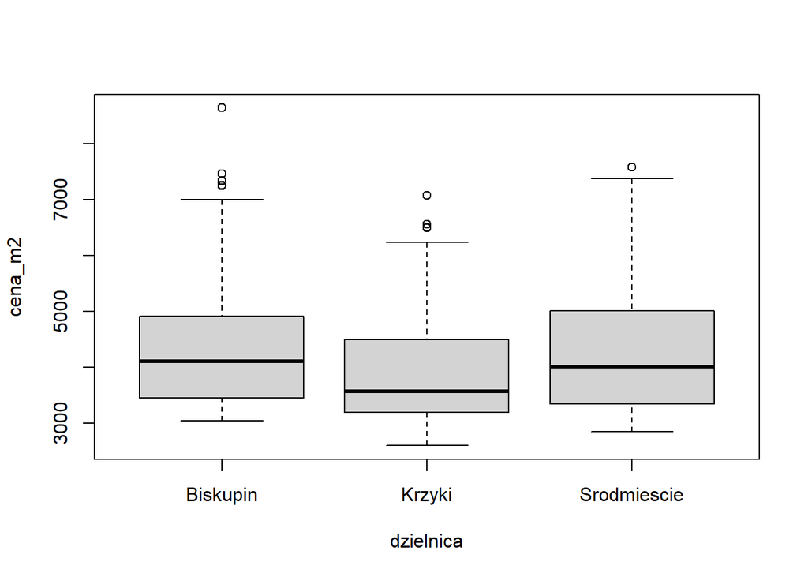

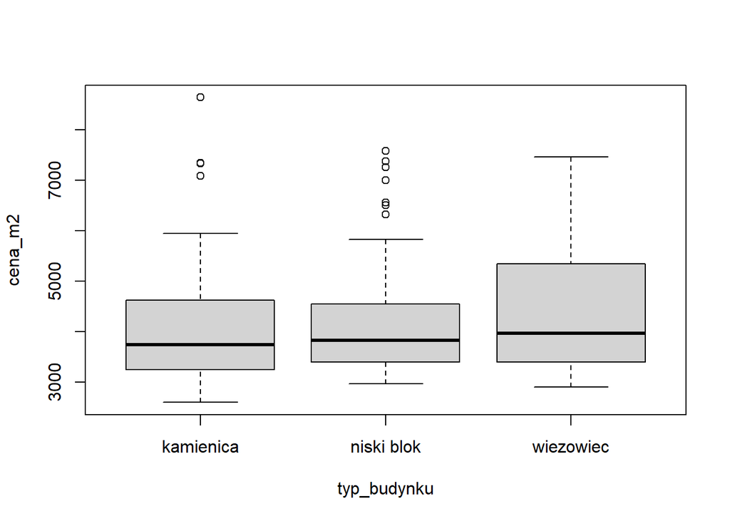

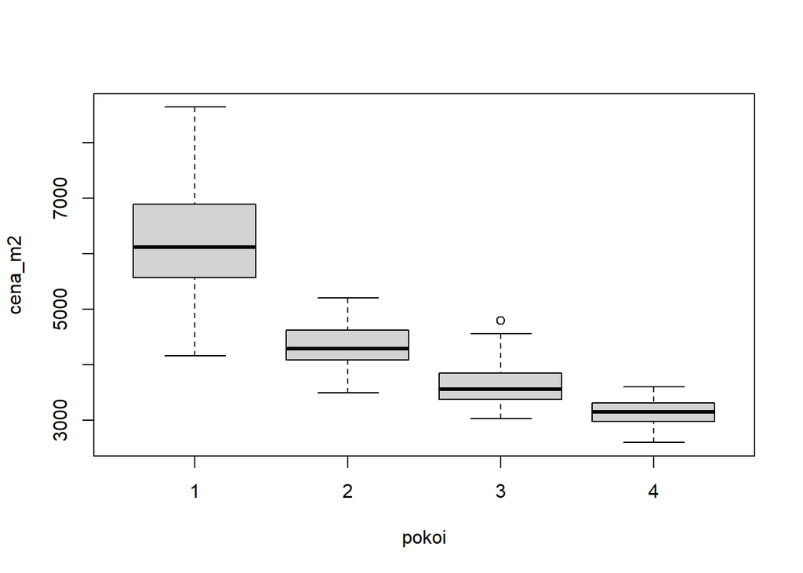

Widzimy, ze w przypadku pierwszych dwoch zmiennych wykresy pudelkowe pokrywaja sie, co swiadczy o dobrym doborze danych lecz widoczna jest spora liczba **outlierow** na co wskazywala dodatnia kurtoza dla obu tych zmiennych.  
W celu usuniecia wartosci odstajacych zbior danych zostal zredukowany o mieszkania 1 i 4 pokojowe.  
Nowy zbior danych wyglada nastepujaco:

```
## tibble [104 x 6] (S3: tbl_df/tbl/data.frame)
##  $ cena        : num [1:104] 181192 194038 192476 174637 170221 ...
##  $ pokoi       : Factor w/ 2 levels "2","3": 2 2 2 2 2 2 2 2 2 2 ...
##  $ powierzchnia: num [1:104] 59.7 62 61.2 55.5 54 45.8 48.3 63.5 57.7 64.7 ...
##  $ dzielnica   : Factor w/ 3 levels "Biskupin","Krzyki",..: 2 2 3 2 2 2 2 2 3 2 ...
##  $ typ_budynku : Factor w/ 3 levels "kamienica","niski blok",..: 1 1 1 3 2 3 3 2 1 3 ...
##  $ cena_m2     : num [1:104] 3035 3130 3145 3147 3152 ...
```

```
## # A tibble: 6 x 6
##      cena pokoi powierzchnia dzielnica   typ_budynku cena_m2
##     <dbl> <fct>        <dbl> <fct>       <fct>         <dbl>
## 1 181192. 3             59.7 Krzyki      kamienica     3035.
## 2 194038. 3             62   Krzyki      kamienica     3130.
## 3 192476. 3             61.2 Srodmiescie kamienica     3145.
## 4 174637. 3             55.5 Krzyki      wiezowiec     3147.
## 5 170221. 3             54   Krzyki      niski blok    3152.
## 6 146475. 3             45.8 Krzyki      wiezowiec     3198.
```

**STATYSTYKI OPISOWE**:

```
## [1] "wsp. zmiennosci dla zmiennej cena_m2 w %"
```

```
## [1] 12.9817
```

Widzimy, ze zmiennosc jest na akceptowalnym poziomie (>10%), chociaz znacznie mniejsza od poprzedniej(przez usuniecie sporej liczby obserwacji).

```
##     item      group1 vars  n    mean     sd  median trimmed    mad     min
## X11    1    Biskupin    1 37 4083.67 510.62 4048.90 4059.24 487.22 3322.21
## X12    2      Krzyki    1 36 3729.28 430.64 3740.48 3710.19 509.25 3035.04
## X13    3 Srodmiescie    1 31 3996.02 533.60 3919.91 3973.80 565.90 3145.04
##         max   range skew kurtosis    se
## X11 5126.70 1804.48 0.24    -0.83 83.95
## X12 4647.40 1612.35 0.26    -0.99 71.77
## X13 5017.03 1871.99 0.36    -1.11 95.84
```

```
##     item     group1 vars  n    mean     sd  median trimmed    mad     min
## X11    1  kamienica    1 33 3948.85 606.56 3869.06 3918.23 772.10 3035.04
## X12    2 niski blok    1 36 3995.49 489.05 4017.54 3976.93 524.84 3152.24
## X13    3  wiezowiec    1 35 3859.34 433.63 3839.93 3833.77 479.67 3146.61
##         max   range skew kurtosis     se
## X11 5126.70 2091.66 0.30    -1.15 105.59
## X12 5017.03 1864.79 0.28    -0.85  81.51
## X13 4914.07 1767.46 0.43    -0.40  73.30
```

```
##     item group1 vars  n    mean     sd  median trimmed    mad     min    max
## X11    1      2    1 48 4309.00 418.59 4271.22 4310.50 392.24 3502.49 5126.7
## X12    2      3    1 56 3614.19 334.76 3536.71 3594.69 348.05 3035.04 4533.3
##       range skew kurtosis    se
## X11 1624.21 0.03    -0.59 60.42
## X12 1498.26 0.54    -0.31 44.73
```

Widzimy, ze jakosc zbioru danych istotnie poprawila sie. Dodatnia kurtoza nie wystepuje.

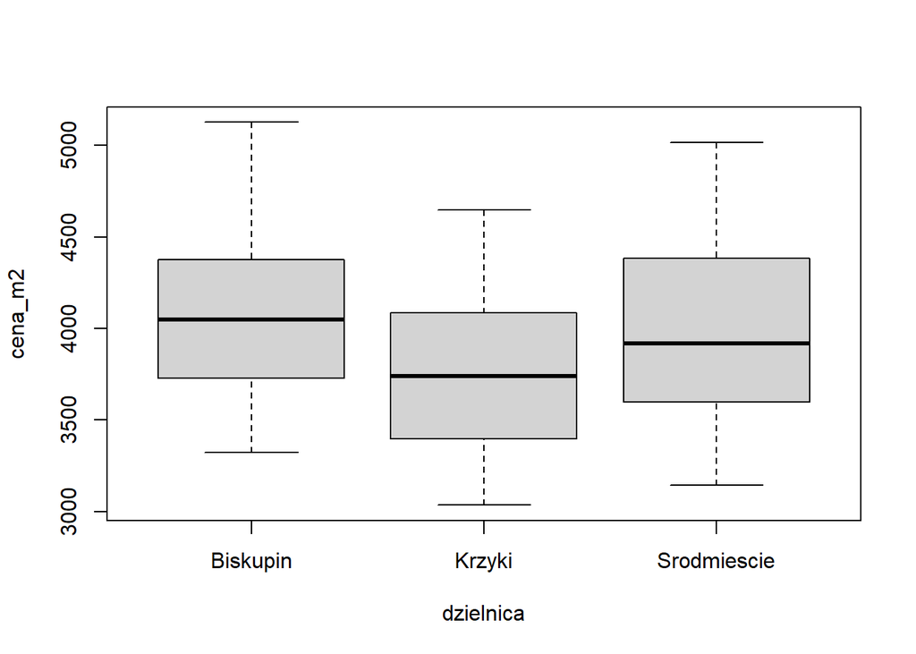

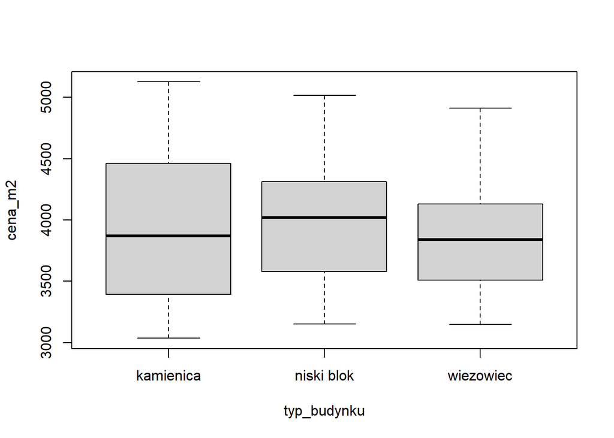

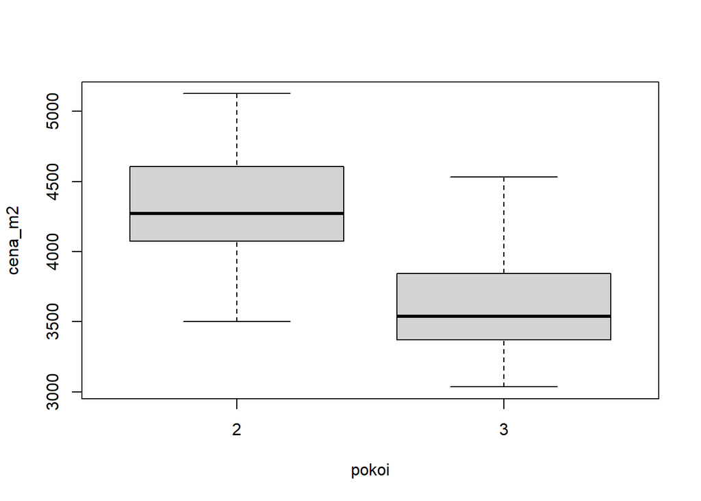

```
## [1] "Wykresy pudelkowe dla kombinacji czynnikow"
```

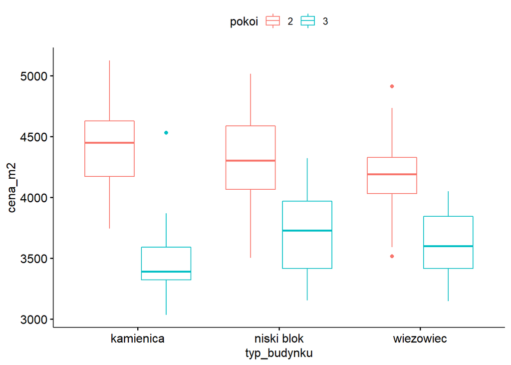

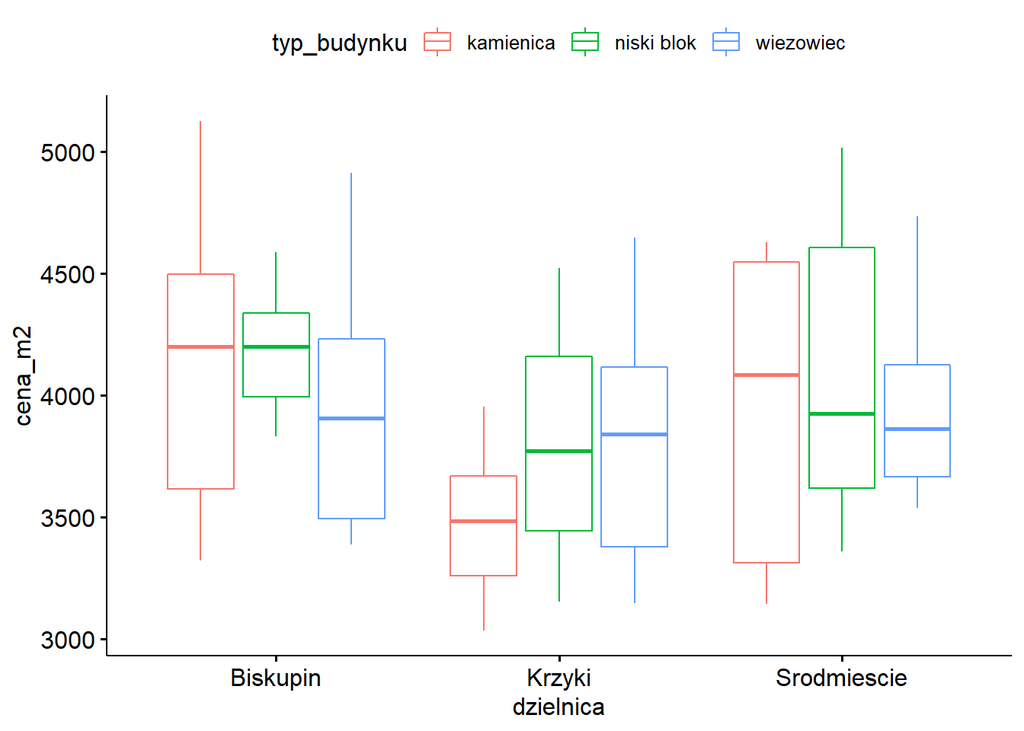

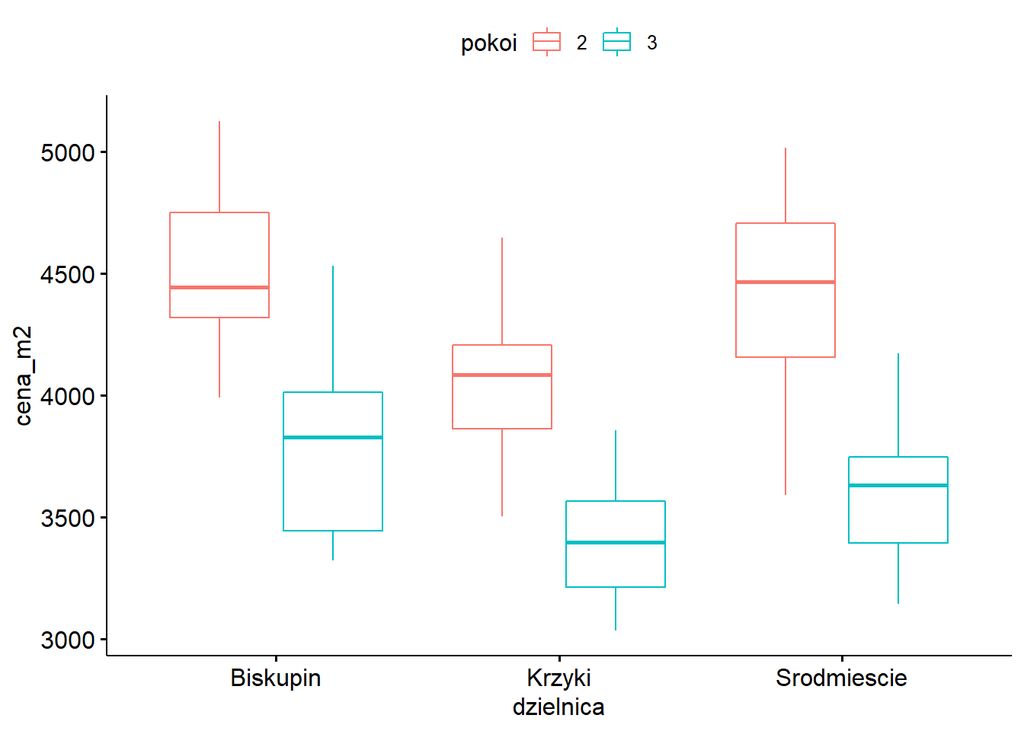

Widzimy, ze redukcja zbioru danych o mieszkania 1 i 4 pokojowe znacznie poprawila sytuacje z wartosciami odstajacymi (brak owych w zbiorze).  
Ponizej widzimy wykresy dla kombinacji czynnikow, **dzielnica:typ_budynku** oraz **dzielnica:pokoi** nie maja wartosci odstajacyh, natomiast **pokoi:typ_budynku** maja owe.  
Skrzynki w przypadku kombinacji **dzielnica:typ_budynku** lepiej “sie pokrywaja”, co wstepnie mowi o mozliwych lepszych wynikach anovy dla tej kombinacji.  
W celach badawczych przyjmujemy wszystkie kombinacji czynnikow.  
##**ROZKLAD NORMALNY oraz HOMOGENICZNOSC WARIANCJI w grupach**

```
## [1] "Liczba mieszkan ze wzgledu na typ budynku w poszczegolnych dzielnicach"
```

```
##              typ_budynku
## dzielnica     kamienica niski blok wiezowiec
##   Biskupin           19          8        10
##   Krzyki              7         14        15
##   Srodmiescie         7         14        10
```

```
## [1] "Liczba mieszkan 2 oraz 3 pokojowych w poszczegolnych dzielnicach"
```

```
##      dzielnica
## pokoi Biskupin Krzyki Srodmiescie
##     2       15     18          15
##     3       22     18          16
```

Popatrzmy na liczbe mieszkan w kombinacji roznych **czynnikow**.  
Widzimy, ze liczba mieszkan w kazdej z grup **NIE** rownoliczna -> wybieramy test homogenocznosci **Bartletta**.  
Dla sprawdzenia normalnosci w grupach zostaly wybrany testy: **Anderson-Darlin**, **Cramer-von Mises** oraz **Shapiro-Francia**.

```
## [1] "Wyniki testow dla cena_m2 i pokoi"
```

```
## $`2`
##
##  Anderson-Darling normality test
##
## data:  X[[i]]
## A = 0.25912, p-value = 0.6999
##
##
## $`3`
##
##  Anderson-Darling normality test
##
## data:  X[[i]]
## A = 0.61211, p-value = 0.1061
```

```
## $`2`
##
##  Cramer-von Mises normality test
##
## data:  X[[i]]
## W = 0.03197, p-value = 0.8144
##
##
## $`3`
##
##  Cramer-von Mises normality test
##
## data:  X[[i]]
## W = 0.10698, p-value = 0.08757
```

```
## $`2`
##
##  Shapiro-Francia normality test
##
## data:  X[[i]]
## W = 0.98414, p-value = 0.6625
##
##
## $`3`
##
##  Shapiro-Francia normality test
##
## data:  X[[i]]
## W = 0.9679, p-value = 0.1252
```

```
## [1] "Wyniki testow dla cena_m2 i dzielnica"
```

```
## $Biskupin
##
##  Anderson-Darling normality test
##
## data:  X[[i]]
## A = 0.43552, p-value = 0.2836
##
##
## $Krzyki
##
##  Anderson-Darling normality test
##
## data:  X[[i]]
## A = 0.40278, p-value = 0.34
##
##
## $Srodmiescie
##
##  Anderson-Darling normality test
##
## data:  X[[i]]
## A = 0.58788, p-value = 0.1171
```

```
## $Biskupin
##
##  Cramer-von Mises normality test
##
## data:  X[[i]]
## W = 0.047128, p-value = 0.5435
##
##
## $Krzyki
##
##  Cramer-von Mises normality test
##
## data:  X[[i]]
## W = 0.06387, p-value = 0.3276
##
##
## $Srodmiescie
##
##  Cramer-von Mises normality test
##
## data:  X[[i]]
## W = 0.095407, p-value = 0.1239
```

```
## $Biskupin
##
##  Shapiro-Francia normality test
##
## data:  X[[i]]
## W = 0.96374, p-value = 0.2269
##
##
## $Krzyki
##
##  Shapiro-Francia normality test
##
## data:  X[[i]]
## W = 0.97232, p-value = 0.4173
##
##
## $Srodmiescie
##
##  Shapiro-Francia normality test
##
## data:  X[[i]]
## W = 0.95689, p-value = 0.2079
```

```
## [1] "Wyniki testow dla cena_m2 i typ_budynku"
```

```
## $kamienica
##
##  Anderson-Darling normality test
##
## data:  X[[i]]
## A = 0.61072, p-value = 0.1031
##
##
## $`niski blok`
##
##  Anderson-Darling normality test
##
## data:  X[[i]]
## A = 0.27308, p-value = 0.647
##
##
## $wiezowiec
##
##  Anderson-Darling normality test
##
## data:  X[[i]]
## A = 0.27641, p-value = 0.6352
```

```
## $kamienica
##
##  Cramer-von Mises normality test
##
## data:  X[[i]]
## W = 0.09483, p-value = 0.1266
##
##
## $`niski blok`
##
##  Cramer-von Mises normality test
##
## data:  X[[i]]
## W = 0.037682, p-value = 0.715
##
##
## $wiezowiec
##
##  Cramer-von Mises normality test
##
## data:  X[[i]]
## W = 0.033929, p-value = 0.781
```

```
## $kamienica
##
##  Shapiro-Francia normality test
##
## data:  X[[i]]
## W = 0.95524, p-value = 0.1655
##
##
## $`niski blok`
##
##  Shapiro-Francia normality test
##
## data:  X[[i]]
## W = 0.97956, p-value = 0.6379
##
##
## $wiezowiec
##
##  Shapiro-Francia normality test
##
## data:  X[[i]]
## W = 0.9744, p-value = 0.4902
```

W przypadku 2-czynnikowej ANOVA nie ma istotnego sensu badac cala probe na rozklad normalny lecz poszczegolne grupy.  
Przyjrzymy sie wynikom testow. Widzimy ze na **poziomie istotnosci = 5%** we wszystkich grupach zachodzi rozklad normalny.  
Zostal wybrany test homogenicznosci **Bartlett**.

```
##
##   Bartlett's Homogeneity Test (alpha = 0.05)
## -----------------------------------------------
##   data : cena_m2 and pokoi
##
##   statistic  : 2.515247
##   parameter  : 1
##   p.value    : 0.1127499
##
##   Result     : Variances are homogeneous.
## -----------------------------------------------
```

```
##
##   Bartlett's Homogeneity Test (alpha = 0.05)
## -----------------------------------------------
##   data : cena_m2 and dzielnica
##
##   statistic  : 1.636148
##   parameter  : 2
##   p.value    : 0.4412808
##
##   Result     : Variances are homogeneous.
## -----------------------------------------------
```

```
##
##   Bartlett's Homogeneity Test (alpha = 0.05)
## -----------------------------------------------
##   data : cena_m2 and typ_budynku
##
##   statistic  : 3.841381
##   parameter  : 2
##   p.value    : 0.1465057
##
##   Result     : Variances are homogeneous.
## -----------------------------------------------
```

Widzimy, ze test **Bartlett** potwierdza rownosc wariancji w kazdej z badanych grup.  
##**ANOVA z INTERAKCJAMI**

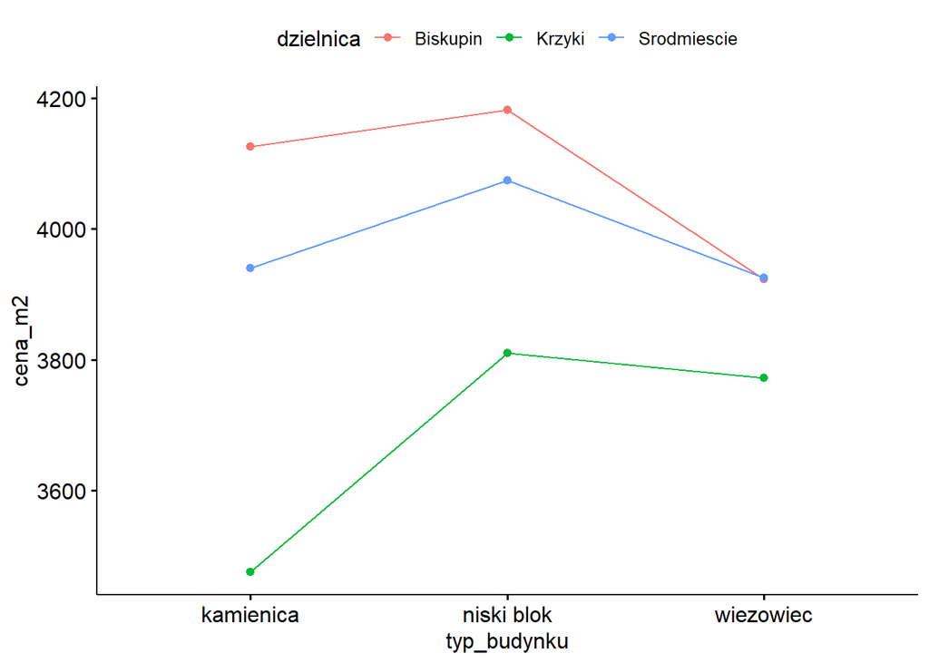

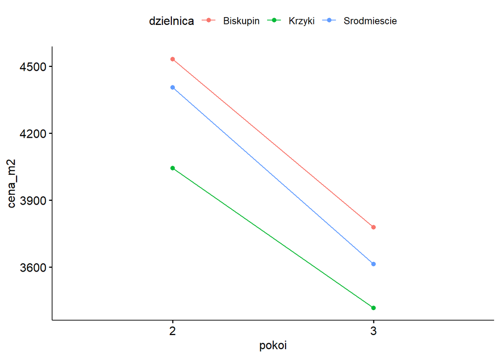

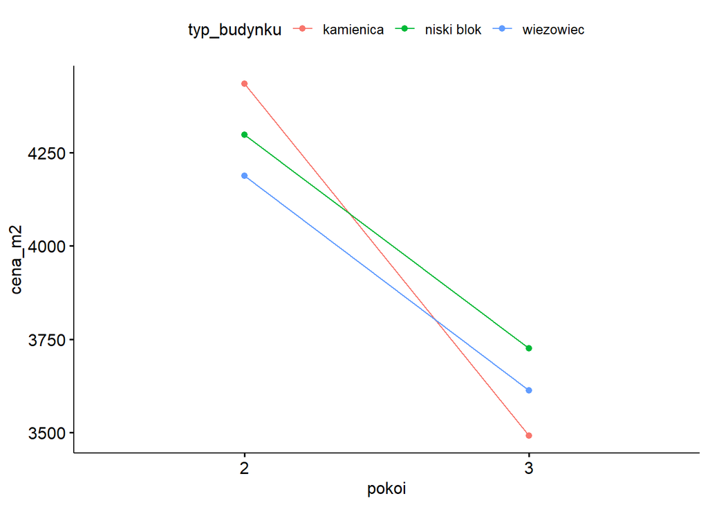

Interpretacja wykresow:  
1. Dla **typ_budynku:dzielnica**, widoczny jest trend w zmianach ceny za m2 -> najpierw wzrost sredniej dla ceny za m2(niski blok jest drozszy), a potem spadek(wiezowiec jest tanszy). W przypadku **wiezowca** w dzielnicach **Biskupin** oraz **Srodmiescie** nastepuje pewna korelacja cen za m2, ale ze wzgledu na poprzednie zachowywanie wykresow jest to **interakcja nie istotna**. Bedzie to udowodnione w nastepnej sekcji projektu.  
2. Dla **pokoi:dzilenica**, widoczny jest trend w zmianach ceny za m2 -> przy zmianie liczby pokoi z 2 na 3 w kazdej dzielnicy nastepuje spadek sredniej ceny za m2, co mowi o braku interakcji czynnikow lecz wplywu kazdego czynnika z osobna.  
3. Dla **pokoi:typ_budynku**, rowniez obserwujemy spadek sredniej ceny za m2 przy zmianie liczby pokoi z 2 na 3. Kluczowym w tym jest to, ze srednia cen za m2 dla kamiennicy 2 pokojowej jest najwyzsza, a po zmianie na liczbe pokoi = 3 srednia cen za m2 dla kamiennicy w porownaniu do pozostalych typow budynku jest **najnizsza**, co wskazuje na **laczny wplyw** czynnikow na zmiane zachowywania sredniej cen za m2 -> zachodzi **effekt interakcji**.

```
## [1] "Wyniki ANOVA dla cena_m2 oraz dzielnica*typ_budynku"
```

```
## Anova Table (Type III tests)
##
## Response: cena_m2
##                          Sum Sq Df   F value  Pr(>F)
## (Intercept)           323526232  1 1317.7694 < 2e-16 ***
## dzielnica               2166418  2    4.4121 0.01471 *
## typ_budynku              369360  2    0.7522 0.47410
## dzielnica:typ_budynku    691865  4    0.7045 0.59078
## Residuals              23323498 95
## ---
## Signif. codes:  0 '***' 0.001 '**' 0.01 '*' 0.05 '.' 0.1 ' ' 1
```

```
## [1] "Wyniki ANOVA dla cena_m2 oraz dzielnica*pokoi"
```

```
## Anova Table (Type III tests)
##
## Response: cena_m2
##                    Sum Sq Df   F value    Pr(>F)
## (Intercept)     308112739  1 2761.0688 < 2.2e-16 ***
## dzielnica         2167758  2    9.7129 0.0001418 ***
## pokoi             5075200  1   45.4800 1.079e-09 ***
## dzielnica:pokoi    132121  2    0.5920 0.5551949
## Residuals        10936000 98
## ---
## Signif. codes:  0 '***' 0.001 '**' 0.01 '*' 0.05 '.' 0.1 ' ' 1
```

```
## [1] "Wyniki ANOVA dla cena_m2 oraz typ_budynku*pokoi"
```

```
## Anova Table (Type III tests)
##
## Response: cena_m2
##                      Sum Sq Df   F value    Pr(>F)
## (Intercept)       314628167  1 2294.7293 < 2.2e-16 ***
## pokoi               7323645  1   53.4147  7.34e-11 ***
## typ_budynku          474739  2    1.7312   0.18243
## pokoi:typ_budynku    762632  2    2.7811   0.06687 .
## Residuals          13436688 98
## ---
## Signif. codes:  0 '***' 0.001 '**' 0.01 '*' 0.05 '.' 0.1 ' ' 1
```

Widzimy, ze wyniki **ANOVA** potwierdzaja poprzednie wykresy, **efekt interakcji** zachodzi tylko w przypadku **pokoi:typ_budynku**(w celach badawczych przyjmujemy, ze p-value = 0,066 jest bliskie 0,05 i dostateczne za uznanie **efektu interakcji**).  
Dla pozostalych dwoch kombinacji bedzie zrobiona **ANOVA** bez interakcji(addytywna).  
Wyniki znajduja sie ponizej.

```
## [1] "Wyniki ANOVA dla cena_m2 oraz dzielnica+typ_budynku bez efektu interakcji"
```

```
## Anova Table (Type III tests)
##
## Response: cena_m2
##                Sum Sq Df   F value    Pr(>F)
## (Intercept) 424569273  1 1750.2279 < 2.2e-16 ***
## dzielnica     2522062  2    5.1984  0.007132 **
## typ_budynku    403724  2    0.8321  0.438134
## Residuals    24015363 99
## ---
## Signif. codes:  0 '***' 0.001 '**' 0.01 '*' 0.05 '.' 0.1 ' ' 1
```

```
## [1] "Wyniki ANOVA dla cena_m2 oraz dzielnica+pokoi bez efektu interakcji"
```

```
## Anova Table (Type III tests)
##
## Response: cena_m2
##                Sum Sq  Df  F value    Pr(>F)
## (Intercept) 499041866   1 4508.822 < 2.2e-16 ***
## dzielnica     3330408   2   15.045  1.94e-06 ***
## pokoi        13350966   1  120.625 < 2.2e-16 ***
## Residuals    11068121 100
## ---
## Signif. codes:  0 '***' 0.001 '**' 0.01 '*' 0.05 '.' 0.1 ' ' 1
```

Z wynikow **ANOVA** dla kombinacji **pokoi:typ_budynku** z interakcjami oraz pozostalych kombinacji bez efektu interakcji widzimy, ze konieczna jest analiza **post-hoc** w celu ustalenia, która z grup wplywa bardziej na brak rownosci srednich w grupach.  
Widzimy, ze nie ma istotnego sensu przeprowadzac analize **post-hoc** dla czynnika **pokoi**, poniewaz jest to tylko 2-poziomowy faktor, dla ktorego juz zostal sprawdzony brak rownosci srednich w grupach (p-value < 0,05).

##**ANALIZA POST-HOC**

```
##
##  Pairwise comparisons using t tests with pooled SD
##
## data:  df23$cena_m2 and df23$dzielnica
##
##             Biskupin Krzyki
## Krzyki      0.008    -
## Srodmiescie 0.466    0.044
##
## P value adjustment method: BH
```

```
##
##  Pairwise comparisons using t tests with pooled SD
##
## data:  df23$cena_m2 and df23$typ_budynku
##
##            kamienica niski blok
## niski blok 0.71      -
## wiezowiec  0.71      0.71
##
## P value adjustment method: BH
```

Widzimy wyniki testow wielokrotnego porownywania dla **czynnikow**. Byla wybrana metoda **BH**.  
Widzimy, ze **p-value < 0,05** wystepuje w przypadku dzielnic **Krzyki** i **Biskupin** oraz **Srodmiescie** i **Krzyki**, co wskazuje na istotne roznice w tych grupach.  
Natomiast, zadna z grup w przypadku **typ_budynku** nie wplywa istotnie (p-value > 0,05).

```
## [1] "Wyniki testu Tukey dla dzielnica oraz typ_budynku"
```

```
##   Tukey multiple comparisons of means
##     95% family-wise confidence level
##
## Fit: aov(formula = cena_m2 ~ dzielnica + typ_budynku, data = df23)
##
## $dzielnica
##                            diff        lwr      upr     p adj
## Krzyki-Biskupin      -354.38727 -628.74504 -80.0295 0.0076350
## Srodmiescie-Biskupin  -87.64781 -372.99966 197.7040 0.7457984
## Srodmiescie-Krzyki    266.73946  -20.41347 553.8924 0.0743608
```

```
## [1] "Wyniki testu Tukey dla dzielnica oraz pokoi"
```

```
##   Tukey multiple comparisons of means
##     95% family-wise confidence level
##
## Fit: aov(formula = cena_m2 ~ dzielnica + pokoi, data = df23)
##
## $dzielnica
##                            diff        lwr       upr     p adj
## Krzyki-Biskupin      -354.38727 -539.68116 -169.0934 0.0000447
## Srodmiescie-Biskupin  -87.64781 -280.36681  105.0712 0.5274129
## Srodmiescie-Krzyki    266.73946   72.80405  460.6749 0.0041494
```

```
## [1] "Wyniki testu Tukey dla pokoi oraz typ_budynku"
```

```
##   Tukey multiple comparisons of means
##     95% family-wise confidence level
##
## Fit: aov(formula = cena_m2 ~ pokoi * typ_budynku, data = df23)
##
## $pokoi
##         diff      lwr      upr p adj
## 3-2 -694.804 -839.341 -550.267     0
##
## $typ_budynku
##                            diff       lwr      upr     p adj
## niski blok-kamienica   55.41752 -156.9548 267.7898 0.8089756
## wiezowiec-kamienica   -50.40335 -264.2217 163.4150 0.8410604
## wiezowiec-niski blok -105.82086 -315.0034 103.3617 0.4537188
##
## $`pokoi:typ_budynku`
##                                diff         lwr       upr     p adj
## 3:kamienica-2:kamienica   -942.6189 -1317.53423 -567.7036 0.0000000
## 2:niski blok-2:kamienica  -136.4239  -511.33924  238.4914 0.8967032
## 3:niski blok-2:kamienica  -709.6252 -1074.84800 -344.4024 0.0000023
## 2:wiezowiec-2:kamienica   -246.8003  -633.64430  140.0437 0.4362596
## 3:wiezowiec-2:kamienica   -821.3186 -1182.34325 -460.2939 0.0000000
## 2:niski blok-3:kamienica   806.1950   437.00392 1175.3861 0.0000001
## 3:niski blok-3:kamienica   232.9937  -126.35048  592.3379 0.4176355
## 2:wiezowiec-3:kamienica    695.8186   314.51975 1077.1175 0.0000103
## 3:wiezowiec-3:kamienica    121.3004  -233.77623  476.3770 0.9191429
## 3:niski blok-2:niski blok -573.2013  -932.54547 -213.8571 0.0001561
## 2:wiezowiec-2:niski blok  -110.3763  -491.67525  270.9225 0.9589229
## 3:wiezowiec-2:niski blok  -684.8946 -1039.97122 -329.8180 0.0000028
## 2:wiezowiec-3:niski blok   462.8249    91.05206  834.5978 0.0060983
## 3:wiezowiec-3:niski blok  -111.6933  -456.52026  233.1336 0.9346219
## 3:wiezowiec-2:wiezowiec   -574.5183  -942.16782 -206.8687 0.0002252
```

##**EFEKTY EKSPEREMENTALNE**

```
## [1] "Wyniki eta.kwadrat oraz czastkowej eta.kwadrat"
```

```
##                       eta.sq eta.sq.part
## pokoi             0.45907815  0.47868883
## typ_budynku       0.00741221  0.01460918
## pokoi:typ_budynku 0.02837614  0.05370906
```

```
## [1] "Wyniki omega.kwadrat"
```

```
##                term omegasq
## 1             pokoi   0.457
## 2       typ_budynku  -0.003
## 3 pokoi:typ_budynku   0.018
```

Widzimy, ze dla kombinacji **pokoi:typ_budynku**, interakcja pomiedzy liczba pokoi a typem_budynku wyjasnia **5,3%** zmiennosci ceny za m2 co jest slabym efektem.  
Calkowita zmiennosc ceny za m2 zostala wyjasniona na **2,8%** w tym przypadku.  
Wplyw wybranych czynnikow dla calej populacji jest na poziomie **1,8%**, co jest slabym efektem.  
Zachodzi nierownosc **eta.kwadrat** > **omegi.kwadrat**, co swiadczy o poprawnosci obliczen.  
Dla pozostalych kombinacji czynnikow **efekty eksperementalne** nie byly liczone, poniewaz nie zachodzil w owych **efekt interakcji** i nie mialoby to sensu.

##**ANALIZA KONCOWA**

**Celem projektu** bylo przeprowadzenie ANOVA 2-czynnikowej oraz ustalenie optymalnej kombinacji **czynnikow**. Tylko w przypadku jednej kombinacji **pokoi:typ_budynku** mialo istotny sens przeprowadzenie ANOVA 2-czynnikowej, poniewaz zachodzil **efekt interakcji**, co potwierdzaja wykresy interakcji. W pozostalych kombinacjach **efektu interakcji** nie bylo (p-value > 0,05), co potwierdzaja wykresy.

```
##                               diff       lwr      upr p adj
## 3:kamienica-2:kamienica   -942.619 -1317.534 -567.704 0.000
## 2:niski blok-2:kamienica  -136.424  -511.339  238.491 0.897
## 3:niski blok-2:kamienica  -709.625 -1074.848 -344.402 0.000
## 2:wiezowiec-2:kamienica   -246.800  -633.644  140.044 0.436
## 3:wiezowiec-2:kamienica   -821.319 -1182.343 -460.294 0.000
## 2:niski blok-3:kamienica   806.195   437.004 1175.386 0.000
## 3:niski blok-3:kamienica   232.994  -126.350  592.338 0.418
## 2:wiezowiec-3:kamienica    695.819   314.520 1077.118 0.000
## 3:wiezowiec-3:kamienica    121.300  -233.776  476.377 0.919
## 3:niski blok-2:niski blok -573.201  -932.545 -213.857 0.000
## 2:wiezowiec-2:niski blok  -110.376  -491.675  270.923 0.959
## 3:wiezowiec-2:niski blok  -684.895 -1039.971 -329.818 0.000
## 2:wiezowiec-3:niski blok   462.825    91.052  834.598 0.006
## 3:wiezowiec-3:niski blok  -111.693  -456.520  233.134 0.935
## 3:wiezowiec-2:wiezowiec   -574.518  -942.168 -206.869 0.000
```

**Eta kwadrat** dla **pokoi:typ_budynku** wyniosla **2,8%**, co interpretujemy jako procent wyjasnionej zmiennosci ceny mieszkania za m2 w modelu 2 czynnikowym.  
**Eta czastkowa kwadrat** wyniosla w tym przypadku **5,3%**, co interpretujemy jako procent wyjasnionej zmiennosci efektu interakcji w modelu z dwoma czynnikami przy pomieniecu wplywu liczby pokoi oraz typu budynku.  
Omega kwadrat wyniosla **1,8%**, co interpretujemy jako procent wyjasnionej calkowitej zmiennosci ceny mieszkania za m2 w skutek interakcji liczby pokoi oraz typu budynku.  
Model nie wyjasnia **51%** zmiennosci ceny mieszkania za m2.

**Hipoteza badawcza** zostala oddalona, poniewaz 2 z 3 kombinacji nie przeszly testu ANOVA (p-value dla interakcji > 0,05) i interpretacja tych kombinacji nie mialaby ostotnego sensu.  
**DZIEKUJE ZA UWAGE**